# 25 | 两个单元测试库：C++里如何进行单元测试?-极客时间

[figure not shown]

# 25 | 两个单元测试库：C++里如何进行单元测试?

2020-01-22 吴咏炜

现代C++实战30讲

[figure not shown]

### 讲述：吴咏炜

[interactive chart not shown]

你好，我是吴咏炜。

单元测试已经越来越成为程序员工作密不可分的一部分了。在 C++ 里，我们当然也是可以很方便地进行单元测试的。今天，我就来介绍两个单元测试库：一个是 Boost.Test [1]，一个是 Catch2 [2]。

## Boost.Test

单元测试库有很多，我选择 Boost 的原因我在上一讲已经说过：“如果我需要某个功能，在标准库里没有，在 Boost 里有，我会很乐意直接使用 Boost 里的方案，而非另外去查找。”再说，Boost.Test 提供的功能还挺齐全的，我需要的都有了。作为开胃小菜，我们先看一个单元测试的小例子：

#define BOOST_TEST_MAIN

#include <boost/test/unit_test.hpp>

#include <stdexcept>

void test(int n)

{

if (n == 42) {

return;

}

throw std::runtime_error(

"Not the answer");

}

BOOST_AUTO_TEST_CASE(my_test)

{

BOOST_TEST_MESSAGE("Testing");

BOOST_TEST(1 + 1 == 2);

BOOST_CHECK_THROW(

test(41), std::runtime_error);

BOOST_CHECK_NO_THROW(test(42));

int expected = 5;

BOOST_TEST(2 + 2 == expected);

BOOST_CHECK(2 + 2 == expected);

}

BOOST_AUTO_TEST_CASE(null_test)

{

}

我们从代码里可以看到：

我们在包含单元测试的头文件之前定义了 BOOST_TEST_MAIN。如果编译时用到了多个源文件，只有一个应该定义该宏。多文件测试的时候，我一般会考虑把这个定义这个宏加包含放在一个单独的文件里（只有两行）。

我们用 BOOST_CHECK 或 BOOST_TEST 来检查一个应当成立的布尔表达式（区别下面会讲）。

我们用 BOOST_CHECK_THROW 来检查一个应当抛出异常的语句。

我们用 BOOST_CHECK_NO_THROW 来检查一个不应当抛出异常的语句。

如 [第 21 讲] 所述，我们可以用下面的命令行来进行编译：

MSVC：cl /DBOOST_TEST_DYN_LINK /EHsc /MD test.cpp

GCC：g++ -DBOOST_TEST_DYN_LINK test.cpp -lboost_unit_test_framework

Clang：clang++ -DBOOST_TEST_DYN_LINK test.cpp -lboost_unit_test_framework

运行结果如下图所示：

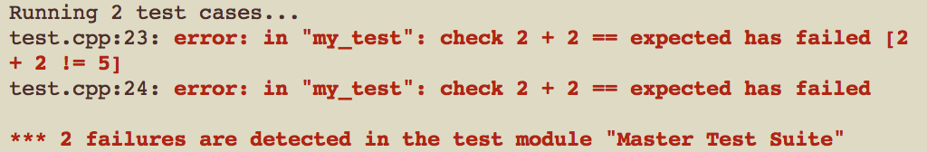

我们现在能看到 BOOST_CHECK 和 BOOST_TEST 的区别了。后者是一个较新加入 Boost.Test 的宏，能利用模板技巧来输出表达式的具体内容。但在某些情况下，BOOST_TEST 试图输出表达式的内容会导致编译出错，这时可以改用更简单的 BOOST_CHECK。

不管是 BOOST_CHECK 还是 BOOST_TEST，在测试失败时，执行仍然会继续。在某些情况下，一个测试失败后继续执行后面的测试已经没有意义，这时，我们就可以考虑使用 BOOST_REQUIRE 或 BOOST_TEST_REQUIRE——表达式一旦失败，整个测试用例会停止执行（但其他测试用例仍会正常执行）。

缺省情况下单元测试的输出只包含错误信息和结果摘要，但输出的详细程度是可以通过命令行选项来进行控制的。如果我们在运行测试程序时加上命令行参数 --log_level=all（或 -l all），我们就可以得到下面这样更详尽的输出：

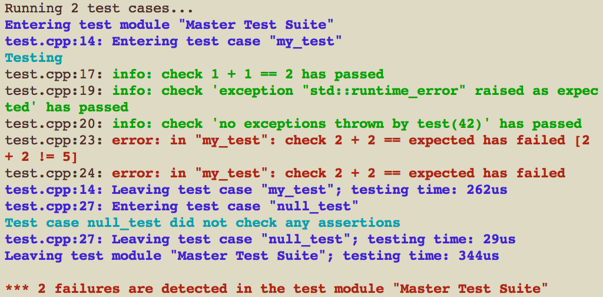

我们现在额外可以看到：

在进入、退出测试模块和用例时的提示

BOOST_TEST_MESSAGE 的输出

正常通过的测试的输出

用例里无测试断言的警告

使用 Windows 的同学如果运行了测试程序的话，多半会惊恐地发现终端上的文字颜色已经发生了变化。这似乎是 Boost.Test 在 Windows 上特有的一个问题：建议你把单元测试的色彩显示关掉。你可以在系统高级设置里添加下面这个环境变量，也可以直接在命令行上输入：

set BOOST_TEST_COLOR_OUTPUT=0

下面我们看一个更真实的例子。

假设我们有一个 split 函数，定义如下：

template <typename String,

typename Delimiter>

class split_view {

public:

typedef

typename String::value_type

char_type;

class iterator { … };

split_view(const String& str,

Delimiter delimiter);

iterator begin() const;

iterator end() const;

vector<basic_string<char_type>>

to_vector() const;

vector<basic_string_view<char_type>>

to_vector_sv() const;

};

template <typename String,

typename Delimiter>

split_view<String, Delimiter>

split(const String& str,

Delimiter delimiter);

这个函数的意图是把类似于字符串的类型（string 或 string_view）分割开，并允许对分割的结果进行遍历。为了方便使用，结果也可以直接转化成字符串的数组（to_vector）或字符串视图的数组（to_vector_sv）。我们不用关心这个函数是如何实现的，我们就需要测试一下，该如何写呢？

首先，当然是写出一个测试用例的框架，把试验的待分割字符串写进去：

BOOST_AUTO_TEST_CASE(split_test)

{

string_view str{

"&grant_type=client_credential"

"&appid="

"&secret=APPSECRET"};

}

最简单直白的测试，显然就是用 to_vector 或 to_vector_sv 来查看结果是否匹配了。这个非常容易加进去：

vector<string>

split_result_expected{

"",

"grant_type=client_"

"credential",

"appid=",

"secret=APPSECRET"};

auto result = split(str, '&');

auto result_s =

result.to_vector();

BOOST_TEST(result_s ==

split_result_expected);

如果 to_vector 实现正确的话，我们现在运行程序就能在终端输出上看到：

*** No errors detected

下面，我们进一步检查 to_vector 和 to_vector_sv 的结果是否一致：

auto result_sv =

result.to_vector_sv();

BOOST_TEST_REQUIRE(

result_s.size() ==

result_sv.size());

{

auto it = result_sv.begin();

for (auto& s : result_s) {

BOOST_TEST(s == *it);

++it;

}

}

最后我们再测试可以遍历 result，并且结果和之前的相同：

size_t i = 0;

auto it = result.begin();

auto end = result.end();

for (; it != end &&

i < result_s.size();

++it) {

BOOST_TEST(*it == result_s[i]);

++i;

}

BOOST_CHECK(it == end);

而这，差不多就接近我实际的 split 测试代码了。完整代码可参见：

https://github.com/adah1972/nvwa/blob/master/test/boosttest_split.cpp

Boost.Test 产生的可执行代码支持很多命令行参数，可以用 --help 命令行选项来查看。常用的有：

build_info 可用来展示构建信息

color_output 可用来打开或关闭输出中的色彩

log_format 可用来指定日志输出的格式，包括纯文本、XML、JUnit 等

log_level 可指定日志输出的级别，有 all、test_suite、error、fatal_error、nothing 等一共 11 个级别

run_test 可选择只运行指定的测试用例

show_progress 可在测试时显示进度，在测试数量较大时比较有用（见下图）

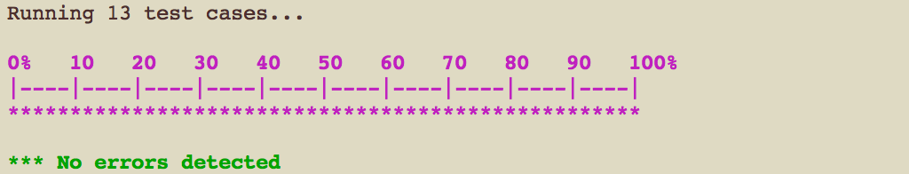

我这儿只是个简单的介绍。完整的 Boost.Test 的功能介绍还是请你自行参看文档。

## Catch2

说完了 Boost.Test，我们再来看一下另外一个单元测试库，Catch2。仍然是和上一讲里说的一样，我要选择 Boost 之外的库，一定有一个比较强的理由。Catch2 有着它自己独有的优点：

只需要单个头文件即可使用，不需要安装和链接，简单方便

可选使用 BDD（Behavior-Driven Development）风格的分节形式

测试失败可选直接进入调试器（Windows 和 macOS 上）

我们拿前面 Boost.Test 的示例直接改造一下：

#define CATCH_CONFIG_MAIN

#include "catch.hpp"

#include <stdexcept>

void test(int n)

{

if (n == 42) {

return;

}

throw std::runtime_error(

"Not the answer");

}

TEST_CASE("My first test", "[my]")

{

INFO("Testing");

CHECK(1 + 1 == 2);

CHECK_THROWS_AS(

test(41), std::runtime_error);

CHECK_NOTHROW(test(42));

int expected = 5;

CHECK(2 + 2 == expected);

}

TEST_CASE("A null test", "[null]")

{

}

可以看到，两者之间的相似性非常多，基本只是宏的名称变了一下。唯一值得一提的，是测试用例的参数：第一项是名字，第二项是标签，可以一个或多个。你除了可以直接在命令行上写测试的名字（不需要选项）来选择运行哪个测试外，也可以写测试的标签来选择运行哪些测试。

这是它在 Windows 下用 MSVC 编译的输出：

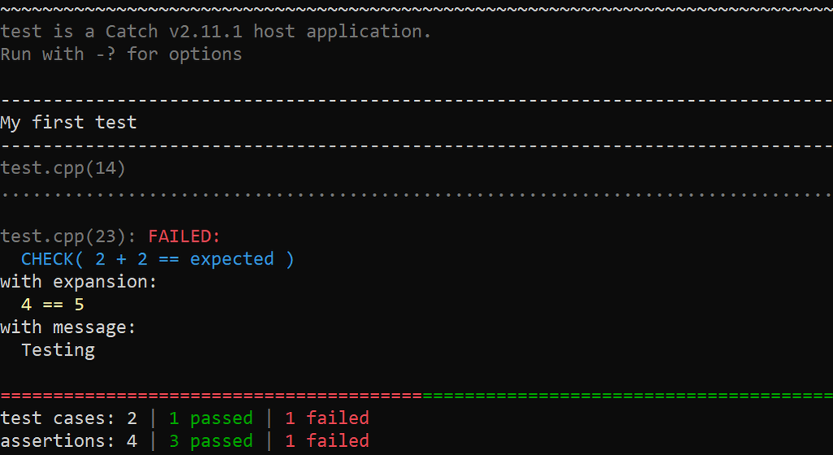

终端的色彩不会被搞乱。缺省的输出清晰程度相当不错。至少在 Windows 下，它看起来可能是个比 Boost.Test 更好的选择。但反过来，在浅色的终端里，Catch2 的色彩不太友好。Boost.Test 在 Linux 和 macOS 下则不管终端的色彩设定，都有比较友好的输出。

和 Boost.Test 类似，Catch2 的测试结果输出格式也是可以修改的。默认格式是纯文本，但你可以通过使用 -r junit 来设成跟 JUnit 兼容的格式，或使用 -r xml 输出成 Catch2 自己的 XML 格式。这方面，它比 Boost.Test 明显易用的一个地方是格式参数大小写不敏感，而在 Boost.Test 里你必须用全大写的形式，如 -f JUNIT，麻烦！

下面我们通过另外一个例子来展示一下所谓的 BDD [3] 风格的测试。

BDD 风格的测试一般采用这样的结构：

Scenario：场景，我要做某某事

Given：给定，已有的条件

When：当，某个事件发生时

Then：那样，就应该发生什么

如果我们要测试一个容器，那代码就应该是这个样子的：

SCENARIO("Int container can be accessed and modified",

"[container]")

{

GIVEN("A container with initialized items")

{

IntContainer c{1, 2, 3, 4, 5};

REQUIRE(c.size() == 5);

WHEN("I access existing items")

{

THEN("The items can be retrieved intact")

{

CHECK(c[0] == 1);

CHECK(c[1] == 2);

CHECK(c[2] == 3);

CHECK(c[3] == 4);

CHECK(c[4] == 5);

}

}

WHEN("I modify items")

{

c[1] = -2;

c[3] = -4;

THEN("Only modified items are changed")

{

CHECK(c[0] == 1);

CHECK(c[1] == -2);

CHECK(c[2] == 3);

CHECK(c[3] == -4);

CHECK(c[4] == 5);

}

}

}

}

你可以在程序前面加上类型定义来测试你自己的容器类或标准容器（如 vector<int>）。这是一种非常直观的写测试的方式。正常情况下，你当然应该看到：

All tests passed (12 assertions in 1 test case)

如果你没有留意到的话，在 GIVEN 里 WHEN 之前的代码是在每次 WHEN 之前都会执行一遍的。这也是 BDD 方式的一个非常方便的地方。

如果测试失败，我们就能看到类似下面这样的信息输出了（我存心制造了一个错误）：

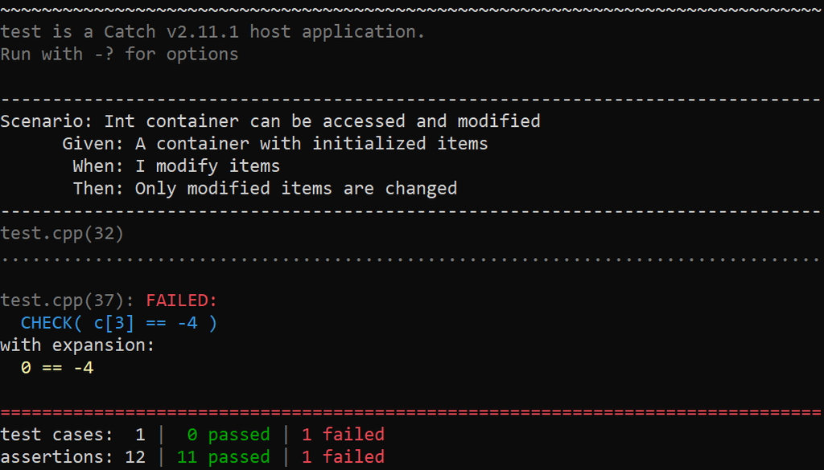

如果没有失败的情况下，想看到具体的测试内容，可以传递参数 --success（或 -s）。

如果你发现 Catch2 的编译速度有点慢的话，那我得告诉你，那是非常正常的。在你沮丧之前，我还应该马上告诉你，这在实际项目中完全不是一个问题。因为慢的原因通常主要是构建 Catch2 的主程序部分，而这部份在项目中只需要做一次，以后不会再有变动。你需要的是分离下面这部分代码在主程序里：

#define CATCH_CONFIG_MAIN

#include "catch.hpp"

只要这两行，来单独编译 Catch2 的主程序部分。你的实际测试代码里，则不要再定义 CATCH_CONFIG_MAIN 了。你会发现，这样一分离后，编译速度会大大加快。事实上，如果 Catch2 的主程序部分不需要编译的话，Catch2 的测试用例的编译速度在我的机器上比 Boost.Test 的还要快。

我觉得 Catch2 是一个很现代、很好用的测试框架。它的宏更简单，一个 CHECK 可以替代 Boost.Test 中的 BOOST_TEST 和 BOOST_CHECK，也没有 BOOST_TEST 在某些情况下不能用、必须换用 BOOST_CHECK 的问题。对于一个新项目，使用 Catch2 应该是件更简单、更容易上手的事——尤其如果你在 Windows 上开发的话。

目前，在 GitHub 上，Catch2 的收藏数超过一万，复刻（fork）数达到一千七，也已经足以证明它的流行程度。

## 内容小结

今天我们介绍了两个单元测试库，Boost.Test 和 Catch2。整体上来看，这两个都是很优秀的单元测试框架，可以满足日常开发的需要。

## 课后思考

请你自己试验一下本讲中的例子，来制造一些成功和失败的情况。使用一下，才能更容易确定哪一个更适合你的需求。

## 参考资料

[1] Gennadiy Rozental and Raffi Enficiaud, Boost.Test. https://www.boost.org/doc/libs/release/libs/test/doc/html/index.html

[2] Two Blue Cubes Ltd., Catch2. https://github.com/catchorg/Catch2

[3] Wikipedia, “Behavior-driven development”. https://en.wikipedia.org/wiki/Behavior-driven_development

[figure not shown]

24 | Boost：你需要的“瑞士军刀”

26 | Easylogging++和spdlog：两个好用的日志库

## 精选留言(3)

[figure not shown]

- 承君此诺

  2020-01-22

  我用的是cmake ctest，个人观点，它很适合测试整个程序，不适合细分到测试某个功能函数。所以，我在看google的gtest。这2个测试框架，您怎么看

  作者回复: 这两个都没有实际使用经验。如果你需要的功能都有，那就没有切换的理由吧。如果不足，就试试其他的。鉴于选择实在太多，重点试几个，满足需求就行了。我一直用 Boost.Test 的理由就是没找到换门的理由，而不是它有多好。当然，至少它是不差的。从下面这个列表里看（几十个 C++ 单元测试框架的概要对比），看起来没有严重缺的东西：  
  https://en.wikipedia.org/wiki/List_of_unit_testing_frameworks#C++

[figure not shown]

- 晚风·和煦

  2020-01-23

  老师，map里面插入成万条数据，如何释放内存呢

  作者回复: 全部清空吗？用clear()有问题？

[figure not shown]

- EricHu

  2020-01-22

  老师，我想请教一下C++的友元类，它会破坏类的封装性，实际在开发中建议使用吗？要怎么做到类似JAVA反射的效果，访问修改内部静态变量

  作者回复: 尽量不用，但有时候必须用啊。比如我在智能指针的实现里就用了。  
  跟Java的比较，你说的情况我不熟。泛泛而言，不要在C++里模拟其他语言的做法。退一步，看你要达到的目的是什么，再看语言有什么机制可以满足目标。C++里目前没反射机制，可预见的将来也大概只会有供编译期使用的静态反射。

[interactive chart not shown]